# Part II - Ford Gobike System Data - February 2019

## Investigation Overview

The goal of this presentation is to showcase some relationships and patterns of features in the dataset. The dataset includes information about individual rides made in February 2019 in the Ford Gobike System Data, a bike-sharing system covering the greater San Francisco Bay area.

**Summary of Insights**

- Although there are more subscribers who use the bike services than customers, customers rode further distances and spent more time riding than subscribers when considering the averages without outliers.
- Generally, there is a trend of high rise of riders in the mornings and evenings of weekdays. While the rides at night and during the twilight period are low everyday, the frequency of rides during the weekends is relatively lower than all other days.
- Average time spent per ride by customers is relatively higher than that spent by subscribers especially on Saturday and Sunday. Average time spent on each ride by each gender type showcases the highest average time spent on weekends by all users. However, the males spend less time than females who spend less than others(those who did not identify as either male or female).
- The relationship between distance and duration shows that, for the majority, there is an increase in duration as distance increases. However, there are some cases where some rides took longer than others even though they covered shorter distances.

## Dataset Overview

> The initial dataset consists of 183412 trip records and 16 attributes which include both numeric and categorical features, the trip records represent the rows while the attributes represent the columns. After cleaning the data and deriving certain features to suit my analysis, the dataset contained 174760 rows and 13 columns.

```python
# import all packages and set plots to be embedded inline
import pandas as pd
import numpy as np
import matplotlib.pyplot as plt
import seaborn as sb
import math

%matplotlib inline

# suppress warnings from final output
import warnings
warnings.simplefilter("ignore")
```

```python
# load in the dataset into a pandas dataframe
ford_2019 = pd.read_csv('ford_gobike_clean.csv')

days = ['Monday', 'Tuesday', 'Wednesday', 'Thursday', 'Friday', 'Saturday', 'Sunday']
day_of_week = pd.api.types.CategoricalDtype(ordered = True, categories = days)
ford_2019['start_day'] = ford_2019['start_day'].astype(day_of_week)


day_time = ['Twilight', 'Morning', 'Afternoon', 'Evening', 'Night']
time_of_day = pd.api.types.CategoricalDtype(ordered = True, categories = day_time)
ford_2019['time_of_day'] = ford_2019['time_of_day'].astype(time_of_day)

ford_2019.member_gender = ford_2019['member_gender'].astype('category')
ford_2019.user_type = ford_2019['user_type'].astype('category')
ford_2019.bike_share_for_all_trip = ford_2019['bike_share_for_all_trip'].astype('category')
```

```python
base_color = sb.color_palette()[0]

actual_time = ford_2019.query('duration_min <= 100')

actual_dist = ford_2019.query('distance <= 10')

dist_dur = ford_2019[(ford_2019.distance <= 10) & (ford_2019.duration_min <= 100)]
```

## User type distribution and relationship with other features

> Although there are more subscribers who use the bike service than customers in the provided dataset, when distance covered and time spent on each ride are considered on the average, we observe that the customers travel much farther distances and and spend more time on rides than subscribers.

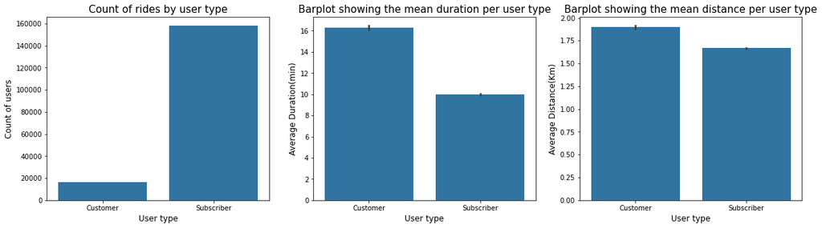

```python
plt.figure(figsize = [20,5])

plt.subplot(1,3,1)
sb.countplot(data = ford_2019, x='user_type', color=base_color)
plt.title('Count of rides by user type', size = 15)
plt.xlabel('User type',size = 12)
plt.ylabel('Count of users', size = 12);

plt.subplot(1,3,2)
sb.barplot(data = actual_time, x='user_type', y='duration_min', color = base_color)
plt.title('Barplot showing the mean duration per user type', size = 15)
plt.xlabel('User type',size = 12)
plt.ylabel('Average Duration(min)', size = 12);

plt.subplot(1,3,3)
sb.barplot(data = actual_dist, x='user_type', y='distance', color = base_color);
plt.title('Barplot showing the mean distance per user type', size = 15)
plt.xlabel('User type', size = 12)
plt.ylabel('Average Distance(Km)', size = 12);
```

## Daily ride useage per time of day

> Generally, there is a trend of high rise of riders in the mornings and evenings of weekdays. While the rides at night and during the twilight period are low everyday, the frequency of rides during the weekends is relatively lower than all other days.

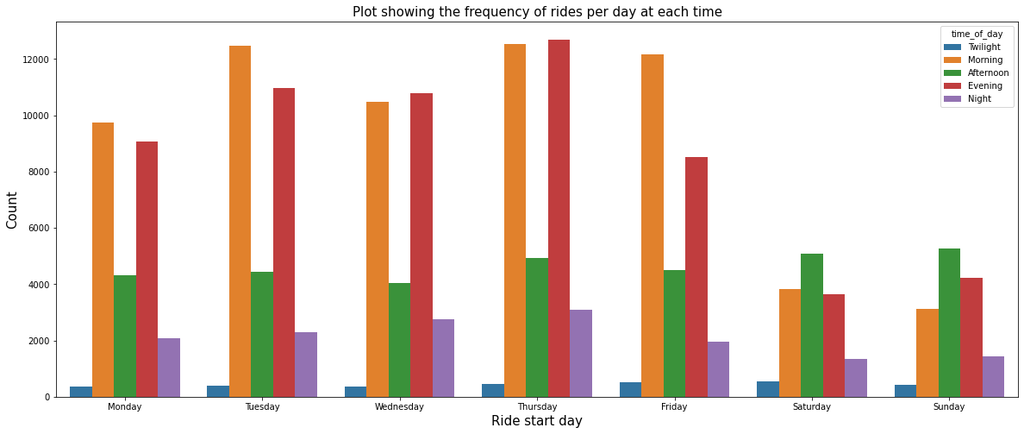

```python
plt.figure(figsize = [20,8])
sb.countplot(data = ford_2019, x= 'start_day', hue = 'time_of_day');

plt.title('Plot showing the frequency of rides per day at each time', size = 15)
plt.ylabel('Count', size = 15)
plt.xlabel('Ride start day', size = 15);
```

## Duration per ride and relationship with gender/user type

- The plot shows that the average time per ride spent by customers is relatively higher than that spent by subscribers especially on Saturday and Sunday. The more relaxed and flexible usage behavior of customers indicates that they use the bike-sharing system in a very different way than their subscribers, presumably for tourism and leisure purposes, and more on weekends.
- Also the plot captures the average time spent on each ride by each gender type, showcasing the highest average time spent on weekends by all users. However, the males spend less time than females who spend less than others(those who did not identify as either male or female). Irrespective of the male gender being the highest amount of users who patronize this bike service, majority of them do not travel long distances or spend time travelling.

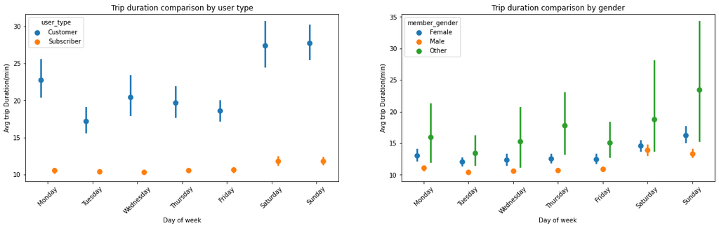

```python
plt.figure(figsize = [20,5])

plt.subplot(1,2,1)
sb.pointplot(data=ford_2019, x='start_day', y='duration_min', hue='user_type', dodge=0.3, linestyles="");

plt.xticks(rotation = 45)
plt.title('Trip duration comparison by user type')
plt.xlabel('Day of week')
plt.ylabel('Avg trip Duration(min)')

plt.subplot(1,2,2)
sb.pointplot(data=ford_2019, x='start_day', y='duration_min', hue='member_gender', dodge=0.3, linestyles="");

plt.xticks(rotation = 45)
plt.title('Trip duration comparison by gender')
plt.xlabel('Day of week')
plt.ylabel('Avg trip Duration(min)');
```

## Distance covered in comparison duration and other features

The plots below show an increase in duration per ride as distance increases.

- The first plot highlights the spreaad of age across the dataset showing that there are very few people aged 60 - 80 who use this bike service. It also highlights most of the users who travel longer distances and spend more time per ride to be aged 20-35 years.
- The second scatterplot displays the distance-duration relationship with the choice of bike sharing per ride. A combination of shared and non shared rides populate the low distance-low duration zone while the farther distance and more time zones are occupied mainly by riders who did not share their trips with a partner.

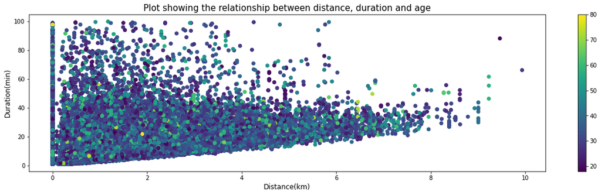

```python
plt.figure(figsize = [20,5])

plt.scatter(data = dist_dur, x = 'distance', y = 'duration_min', c = 'age')
plt.colorbar();

plt.title('Plot showing the relationship between distance, duration and age', size = 15)
plt.ylabel('Duration(min)', size = 12)
plt.xlabel('Distance(km)', size = 12);
```

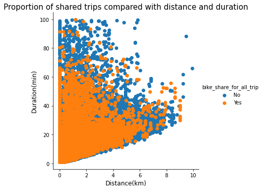

```python
g = sb.FacetGrid(data = dist_dur, hue = 'bike_share_for_all_trip', size = 5)
g.map(plt.scatter, 'distance', 'duration_min')
g.add_legend()

plt.title('Proportion of shared trips compared with distance and duration', size = 15)
plt.ylabel('Duration(min)', size = 12)
plt.xlabel('Distance(km)', size = 12);
```

```python
# generate slideshow
!jupyter nbconvert Part_II_slide_deck_template.ipynb --to slides --post serve --no-input --no-prompt
```

[output not shown]